# Analyse colocalisation of pericardial fat GWAS

Aaron Wagen

UCL

23 July 2023

```r
# Set path
here::i_am("docs/analyse_peridard_fat_gwas_coloc.Rmd")
```

```r
args <- list(
   coloc_results_summary_file = here::here("processed_data",
                                          "coloc",
                                          "coloc_summary.Rds"),
   coloc_results_dir = here::here("processed_data",
                                  "coloc"),
   coloc_figure_path = here::here("figures"),
   raw_data_dir = here::here("raw_data"),
    eqtl_gtf_gencode_26_file = "~/references/GRCh38/annotation/gencode.v26.annotation.gtf.gz"
)
```

```r
source(here::here("scripts",
                  "colochelpr_functions.R"))

munge_gtex8_eqtl_for_analysis <- function(eqtl_df){
  #' Function that munges the raw gtex8 eqtl for use with colochelpR
  #' @param eqtl_df loaded eqtl dataframe
  #' @param T/F whether to add in the sample number from the eqtl lookup table. Required in running coloc, but not in exploring loci during analysis.
  #' @return dataframe munged for coloc

  eqtl_df <- eqtl_df %>%
    dplyr::mutate(eqtl_dataset = eqtl_name,
                  gene = str_replace(gene_id, "\\..*$", "")) %>%  #remove suffix digit from gene_id%>%
    separate(variant_id,
             into = c("CHR", "BP", "Al2", "Al1", "GRCh"), #split variant column into snp identifier columns. The first column is the ref column (Al2), the second is the alt/effect column (AL1)
             sep = "_") %>%
    change_CHR_gencode_to_ensembl(.) %>%    # change gencode Chr format to ensembl
    generate_location_based_SNP_column() %>%
    left_join(.,
              gtf,
              by = "gene_id") %>%
    dplyr::select(eqtl_dataset, gene, gene_name, SNP, CHR, BP, beta = slope, se = slope_se, p.value = pval_nominal, Al1, Al2, maf)  %>%
    get_varbeta() %>%
    change_indels() %>%
    remove_duplicated_snps()

  return(eqtl_df)

}
```

> Aim: The aim of this analysis is to explore the significant loci in a pericardial fat MRI imaging-genetics GWAS study using colocalisation analysis with expression QTL results from adipose tissue in GTEx8.

# 1 Background

# 2 Colocalisation

Coloc uses a Bayesian approach to test the following hypotheses:

- H0: No association with either trait.
- H1: Association with trait 1, not with trait 2.
- H2: Association with trait 2, not with trait 1.
- H3: Association with trait 1 and 2, two independent SNPs.
- **H4: Association with trait 1 and trait 2, one shared SNP.** This is the one of greatest interest to us, where PPH4 > 0.75 (and especially >0.9) is considered significant.

The prior probabilities for the Beyesian framework were specified as follows:

- p1: the prior probability that any random SNP in the region is associated with trait 1 [coloc default, 1e-04]
- p2: the prior probability that any random SNP in the region is associated with trait 2 [coloc default, 1e-04]
- p12: the prior probability that any random SNP in the region is associated with both traits. Coloc was run using a liberal [1e-05, the coloc default] and a robust p12 [5e-06]

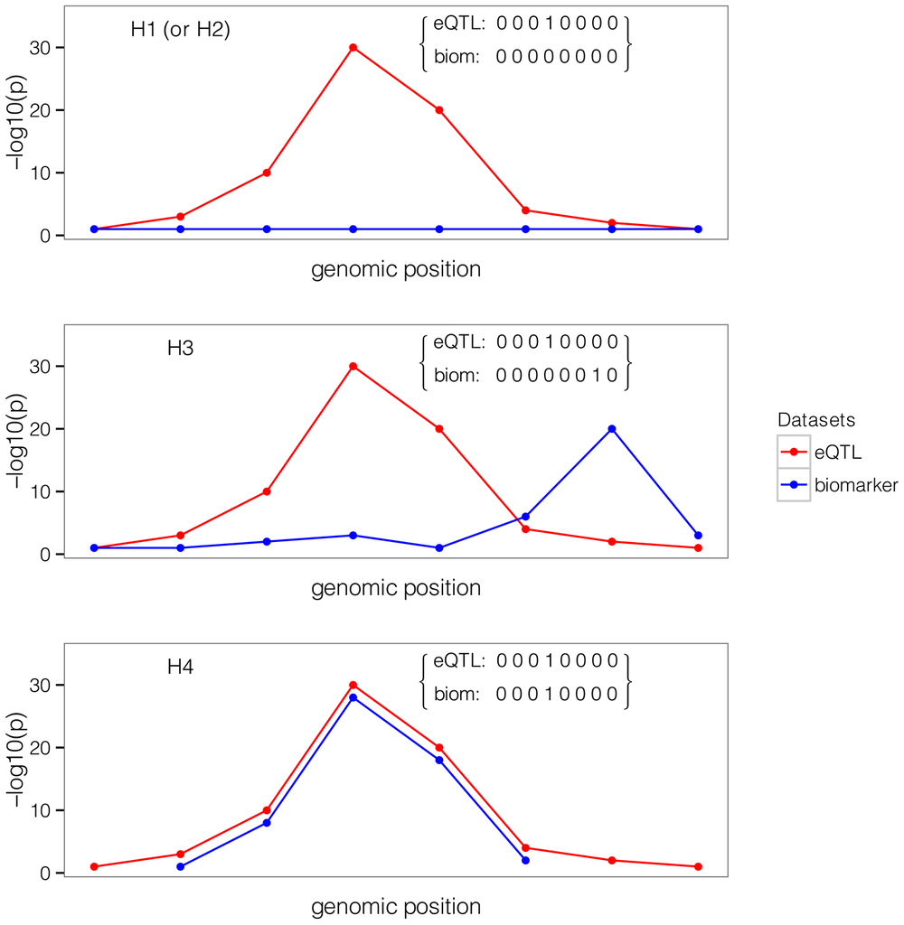

This analysis utilises the wrapper functions within the colochelper package, written by David Zhang and Regina Reynolds.

# 3 Methods:

Coloc was run using the following scripts:

```r
# This script was used to run coloc
source(here::here("scripts", "01_munge_GWASs_for_coloc.R"))

source(here::here("scripts", "02_run_coloc_pericard-fat_gtex-adipose.R"))

source(here::here("scripts", "03_process_coloc_results_pericard-fat_gtex-adipose.R"))
```

# 4 Results

Using the liberal priors, the RP4-712E4.1 locus was strongly positive in the discovery GWAS in subcutaneous fat (PPH4 92%), and in the tibial artery (PPH4 96%). This result was not seen in the replication GWAS. The next closest was TBX15 which had a posterior probability of hypothesis 4 of 53% in the left ventricle.  
Also note that the PPH3 for WARS2 and RP11-418J17.1 was very high (>99%) in all tissues in the discovery dataset, though not in the replication dataset, suggesting that many independent SNPs are modifying the gene expression and PAT at that locus.

```r
all_results <- readRDS(args$coloc_results_summary_file)
```

```r
prior_type <- "liberal"
results <- all_results[[prior_type]]


results_list <- results %>%
  group_split(eqtl) %>%
  setNames(unique(results$eqtl))
```

## 4.1 All results - tables

### 4.1.1 Adipose_Subcutaneous

Table 4.1: Adipose_Subcutaneous eQTL Results

| GWAS_1 | eqtl | gene_2 | gene_name | nsnps | PP.H0.abf | PP.H1.abf | PP.H2.abf | PP.H3.abf | PP.H4.abf | sum_PPH3_PPH4 | ratio_PPH4_PPH3 | p12 |
| --- | --- | --- | --- | --- | --- | --- | --- | --- | --- | --- | --- | --- |
| pat_discovery | Adipose_Subcutaneous | ENSG00000092607 | TBX15 | 1297 | 0.65933 | 0.02922 | 0.28421 | 0.01258 | 0.01465 | 0.02723 | 1.16417 | 1e-05 |
| pat_discovery | Adipose_Subcutaneous | ENSG00000116874 | WARS2 | 1845 | 0.00000 | 0.00000 | 0.00185 | 0.99291 | 0.00524 | 0.99815 | 0.00527 | 1e-05 |
| pat_discovery | Adipose_Subcutaneous | ENSG00000221818 | EBF2 | 7556 | 0.00000 | 0.48364 | 0.00000 | 0.49855 | 0.01781 | 0.51635 | 0.03572 | 1e-05 |
| pat_discovery | Adipose_Subcutaneous | ENSG00000226172 | RP4-712E4.1 | 1133 | 0.00000 | 0.00000 | 0.00474 | 0.06783 | 0.92743 | 0.99526 | 13.67282 | 1e-05 |
| pat_discovery | Adipose_Subcutaneous | ENSG00000231365 | RP11-418J17.1 | 1227 | 0.00000 | 0.00000 | 0.00141 | 0.99858 | 0.00001 | 0.99859 | 0.00001 | 1e-05 |
| pat_replication | Adipose_Subcutaneous | ENSG00000092607 | TBX15 | 1297 | 0.58436 | 0.06585 | 0.25190 | 0.02832 | 0.06957 | 0.09789 | 2.45717 | 1e-05 |
| pat_replication | Adipose_Subcutaneous | ENSG00000116874 | WARS2 | 1844 | 0.00000 | 0.00000 | 0.63907 | 0.25347 | 0.10746 | 0.36093 | 0.42398 | 1e-05 |
| pat_replication | Adipose_Subcutaneous | ENSG00000221818 | EBF2 | 7555 | 0.00003 | 0.48362 | 0.00003 | 0.49852 | 0.01781 | 0.51633 | 0.03572 | 1e-05 |
| pat_replication | Adipose_Subcutaneous | ENSG00000226172 | RP4-712E4.1 | 1135 | 0.00000 | 0.00000 | 0.92369 | 0.04630 | 0.03001 | 0.07631 | 0.64819 | 1e-05 |
| pat_replication | Adipose_Subcutaneous | ENSG00000231365 | RP11-418J17.1 | 1227 | 0.00000 | 0.00000 | 0.90932 | 0.07935 | 0.01133 | 0.09068 | 0.14276 | 1e-05 |

### 4.1.2 Adipose_Visceral_Omentum

Table 4.1: Adipose_Visceral_Omentum eQTL Results

| GWAS_1 | eqtl | gene_2 | gene_name | nsnps | PP.H0.abf | PP.H1.abf | PP.H2.abf | PP.H3.abf | PP.H4.abf | sum_PPH3_PPH4 | ratio_PPH4_PPH3 | p12 |
| --- | --- | --- | --- | --- | --- | --- | --- | --- | --- | --- | --- | --- |
| pat_discovery | Adipose_Visceral_Omentum | ENSG00000092607 | TBX15 | 1458 | 0.60912 | 0.06800 | 0.25895 | 0.02887 | 0.03506 | 0.06393 | 1.21415 | 1e-05 |
| pat_discovery | Adipose_Visceral_Omentum | ENSG00000116874 | WARS2 | 1812 | 0.00000 | 0.00000 | 0.00216 | 0.99747 | 0.00037 | 0.99784 | 0.00037 | 1e-05 |
| pat_discovery | Adipose_Visceral_Omentum | ENSG00000221818 | EBF2 | 7556 | 0.00000 | 0.59759 | 0.00000 | 0.37435 | 0.02806 | 0.40241 | 0.07496 | 1e-05 |
| pat_discovery | Adipose_Visceral_Omentum | ENSG00000231365 | RP11-418J17.1 | 2233 | 0.00000 | 0.00000 | 0.00125 | 0.99874 | 0.00001 | 0.99875 | 0.00001 | 1e-05 |
| pat_replication | Adipose_Visceral_Omentum | ENSG00000092607 | TBX15 | 1458 | 0.64251 | 0.04893 | 0.27314 | 0.02078 | 0.01464 | 0.03542 | 0.70423 | 1e-05 |
| pat_replication | Adipose_Visceral_Omentum | ENSG00000116874 | WARS2 | 1813 | 0.00000 | 0.00000 | 0.80871 | 0.17502 | 0.01627 | 0.19129 | 0.09294 | 1e-05 |
| pat_replication | Adipose_Visceral_Omentum | ENSG00000221818 | EBF2 | 7555 | 0.00003 | 0.59759 | 0.00002 | 0.37430 | 0.02806 | 0.40236 | 0.07497 | 1e-05 |
| pat_replication | Adipose_Visceral_Omentum | ENSG00000231365 | RP11-418J17.1 | 2233 | 0.00000 | 0.00000 | 0.73156 | 0.25895 | 0.00949 | 0.26844 | 0.03666 | 1e-05 |

### 4.1.3 Artery_Aorta

Table 4.1: Artery_Aorta eQTL Results

| GWAS_1 | eqtl | gene_2 | gene_name | nsnps | PP.H0.abf | PP.H1.abf | PP.H2.abf | PP.H3.abf | PP.H4.abf | sum_PPH3_PPH4 | ratio_PPH4_PPH3 | p12 |
| --- | --- | --- | --- | --- | --- | --- | --- | --- | --- | --- | --- | --- |
| pat_discovery | Artery_Aorta | ENSG00000092607 | TBX15 | 1426 | 0.51874 | 0.03889 | 0.13935 | 0.01015 | 0.29287 | 0.30302 | 28.84359 | 1e-05 |
| pat_discovery | Artery_Aorta | ENSG00000116874 | WARS2 | 1859 | 0.00000 | 0.00000 | 0.00211 | 0.99020 | 0.00769 | 0.99789 | 0.00777 | 1e-05 |
| pat_discovery | Artery_Aorta | ENSG00000221818 | EBF2 | 7556 | 0.00000 | 0.56162 | 0.00000 | 0.40098 | 0.03740 | 0.43838 | 0.09326 | 1e-05 |
| pat_discovery | Artery_Aorta | ENSG00000231365 | RP11-418J17.1 | 2217 | 0.00000 | 0.00000 | 0.00126 | 0.99873 | 0.00001 | 0.99874 | 0.00001 | 1e-05 |
| pat_replication | Artery_Aorta | ENSG00000092607 | TBX15 | 1426 | 0.72538 | 0.05020 | 0.19486 | 0.01347 | 0.01610 | 0.02956 | 1.19506 | 1e-05 |
| pat_replication | Artery_Aorta | ENSG00000116874 | WARS2 | 1859 | 0.00000 | 0.00000 | 0.64997 | 0.20920 | 0.14083 | 0.35003 | 0.67315 | 1e-05 |
| pat_replication | Artery_Aorta | ENSG00000221818 | EBF2 | 7555 | 0.00003 | 0.56160 | 0.00002 | 0.40095 | 0.03739 | 0.43835 | 0.09327 | 1e-05 |
| pat_replication | Artery_Aorta | ENSG00000231365 | RP11-418J17.1 | 2218 | 0.00000 | 0.00000 | 0.78893 | 0.20129 | 0.00978 | 0.21107 | 0.04856 | 1e-05 |

### 4.1.4 Artery_Coronary

Table 4.1: Artery_Coronary eQTL Results

| GWAS_1 | eqtl | gene_2 | gene_name | nsnps | PP.H0.abf | PP.H1.abf | PP.H2.abf | PP.H3.abf | PP.H4.abf | sum_PPH3_PPH4 | ratio_PPH4_PPH3 | p12 |
| --- | --- | --- | --- | --- | --- | --- | --- | --- | --- | --- | --- | --- |
| pat_discovery | Artery_Coronary | ENSG00000092607 | TBX15 | 2032 | 0.43506 | 0.18921 | 0.23179 | 0.10076 | 0.04318 | 0.14394 | 0.42849 | 1e-05 |
| pat_discovery | Artery_Coronary | ENSG00000116874 | WARS2 | 2316 | 0.00000 | 0.00000 | 0.00181 | 0.99280 | 0.00540 | 0.99819 | 0.00543 | 1e-05 |
| pat_discovery | Artery_Coronary | ENSG00000221818 | EBF2 | 7556 | 0.00000 | 0.55062 | 0.00000 | 0.41237 | 0.03701 | 0.44938 | 0.08976 | 1e-05 |
| pat_discovery | Artery_Coronary | ENSG00000231365 | RP11-418J17.1 | 1155 | 0.00000 | 0.00000 | 0.00141 | 0.99858 | 0.00001 | 0.99859 | 0.00001 | 1e-05 |
| pat_replication | Artery_Coronary | ENSG00000092607 | TBX15 | 2032 | 0.56498 | 0.07906 | 0.30101 | 0.04211 | 0.01285 | 0.05496 | 0.30526 | 1e-05 |
| pat_replication | Artery_Coronary | ENSG00000116874 | WARS2 | 2317 | 0.00000 | 0.00000 | 0.62772 | 0.26101 | 0.11127 | 0.37228 | 0.42630 | 1e-05 |
| pat_replication | Artery_Coronary | ENSG00000221818 | EBF2 | 7555 | 0.00003 | 0.55066 | 0.00002 | 0.41227 | 0.03702 | 0.44929 | 0.08978 | 1e-05 |
| pat_replication | Artery_Coronary | ENSG00000231365 | RP11-418J17.1 | 1155 | 0.00000 | 0.00000 | 0.90661 | 0.08211 | 0.01128 | 0.09339 | 0.13735 | 1e-05 |

### 4.1.5 Artery_Tibial

Table 4.1: Artery_Tibial eQTL Results

| GWAS_1 | eqtl | gene_2 | gene_name | nsnps | PP.H0.abf | PP.H1.abf | PP.H2.abf | PP.H3.abf | PP.H4.abf | sum_PPH3_PPH4 | ratio_PPH4_PPH3 | p12 |
| --- | --- | --- | --- | --- | --- | --- | --- | --- | --- | --- | --- | --- |
| pat_discovery | Artery_Tibial | ENSG00000092607 | TBX15 | 1176 | 0.75569 | 0.02956 | 0.20064 | 0.00784 | 0.00626 | 0.01410 | 0.79826 | 1e-05 |
| pat_discovery | Artery_Tibial | ENSG00000116874 | WARS2 | 1367 | 0.00000 | 0.00000 | 0.00212 | 0.99179 | 0.00609 | 0.99788 | 0.00614 | 1e-05 |
| pat_discovery | Artery_Tibial | ENSG00000221818 | EBF2 | 7556 | 0.00000 | 0.00047 | 0.00000 | 0.99950 | 0.00003 | 0.99953 | 0.00003 | 1e-05 |
| pat_discovery | Artery_Tibial | ENSG00000226172 | RP4-712E4.1 | 1253 | 0.00000 | 0.00000 | 0.00554 | 0.03087 | 0.96359 | 0.99446 | 31.21326 | 1e-05 |
| pat_discovery | Artery_Tibial | ENSG00000231365 | RP11-418J17.1 | 1706 | 0.00000 | 0.00000 | 0.00127 | 0.99872 | 0.00001 | 0.99873 | 0.00001 | 1e-05 |
| pat_replication | Artery_Tibial | ENSG00000092607 | TBX15 | 1176 | 0.74444 | 0.03999 | 0.19765 | 0.01061 | 0.00730 | 0.01791 | 0.68768 | 1e-05 |
| pat_replication | Artery_Tibial | ENSG00000116874 | WARS2 | 1367 | 0.00000 | 0.00000 | 0.64160 | 0.24946 | 0.10894 | 0.35840 | 0.43668 | 1e-05 |
| pat_replication | Artery_Tibial | ENSG00000221818 | EBF2 | 7555 | 0.00000 | 0.00047 | 0.00005 | 0.99943 | 0.00005 | 0.99948 | 0.00005 | 1e-05 |
| pat_replication | Artery_Tibial | ENSG00000226172 | RP4-712E4.1 | 1255 | 0.00000 | 0.00000 | 0.91331 | 0.05611 | 0.03059 | 0.08669 | 0.54515 | 1e-05 |
| pat_replication | Artery_Tibial | ENSG00000231365 | RP11-418J17.1 | 1705 | 0.00000 | 0.00000 | 0.86620 | 0.12308 | 0.01072 | 0.13380 | 0.08712 | 1e-05 |

### 4.1.6 Heart_Atrial_Appendage

Table 4.1: Heart_Atrial_Appendage eQTL Results

| GWAS_1 | eqtl | gene_2 | gene_name | nsnps | PP.H0.abf | PP.H1.abf | PP.H2.abf | PP.H3.abf | PP.H4.abf | sum_PPH3_PPH4 | ratio_PPH4_PPH3 | p12 |
| --- | --- | --- | --- | --- | --- | --- | --- | --- | --- | --- | --- | --- |
| pat_discovery | Heart_Atrial_Appendage | ENSG00000092607 | TBX15 | 1757 | 0.00209 | 0.16793 | 0.00557 | 0.44633 | 0.37808 | 0.82441 | 0.84709 | 1e-05 |
| pat_discovery | Heart_Atrial_Appendage | ENSG00000116874 | WARS2 | 2008 | 0.00000 | 0.00000 | 0.00211 | 0.99193 | 0.00596 | 0.99789 | 0.00601 | 1e-05 |
| pat_discovery | Heart_Atrial_Appendage | ENSG00000221818 | EBF2 | 7556 | 0.00000 | 0.47060 | 0.00000 | 0.50511 | 0.02429 | 0.52940 | 0.04810 | 1e-05 |
| pat_discovery | Heart_Atrial_Appendage | ENSG00000231365 | RP11-418J17.1 | 1738 | 0.00000 | 0.00000 | 0.00141 | 0.99858 | 0.00001 | 0.99859 | 0.00001 | 1e-05 |
| pat_replication | Heart_Atrial_Appendage | ENSG00000092607 | TBX15 | 1757 | 0.20656 | 0.04510 | 0.54946 | 0.11988 | 0.07901 | 0.19888 | 0.65907 | 1e-05 |
| pat_replication | Heart_Atrial_Appendage | ENSG00000116874 | WARS2 | 2008 | 0.00000 | 0.00000 | 0.68765 | 0.19670 | 0.11565 | 0.31235 | 0.58793 | 1e-05 |
| pat_replication | Heart_Atrial_Appendage | ENSG00000221818 | EBF2 | 7555 | 0.00002 | 0.47058 | 0.00003 | 0.50507 | 0.02429 | 0.52937 | 0.04810 | 1e-05 |
| pat_replication | Heart_Atrial_Appendage | ENSG00000231365 | RP11-418J17.1 | 1739 | 0.00000 | 0.00000 | 0.86626 | 0.12290 | 0.01084 | 0.13374 | 0.08819 | 1e-05 |

### 4.1.7 Heart_Left_Ventricle

Table 4.1: Heart_Left_Ventricle eQTL Results

| GWAS_1 | eqtl | gene_2 | gene_name | nsnps | PP.H0.abf | PP.H1.abf | PP.H2.abf | PP.H3.abf | PP.H4.abf | sum_PPH3_PPH4 | ratio_PPH4_PPH3 | p12 |
| --- | --- | --- | --- | --- | --- | --- | --- | --- | --- | --- | --- | --- |
| pat_discovery | Heart_Left_Ventricle | ENSG00000092607 | TBX15 | 1458 | 0.00404 | 0.33282 | 0.00157 | 0.12890 | 0.53268 | 0.66158 | 4.13267 | 1e-05 |
| pat_discovery | Heart_Left_Ventricle | ENSG00000116874 | WARS2 | 2025 | 0.00000 | 0.00000 | 0.00216 | 0.99638 | 0.00147 | 0.99784 | 0.00147 | 1e-05 |
| pat_discovery | Heart_Left_Ventricle | ENSG00000221818 | EBF2 | 7556 | 0.00000 | 0.51345 | 0.00000 | 0.45686 | 0.02969 | 0.48654 | 0.06498 | 1e-05 |
| pat_discovery | Heart_Left_Ventricle | ENSG00000231365 | RP11-418J17.1 | 2019 | 0.00000 | 0.00000 | 0.00139 | 0.99859 | 0.00001 | 0.99861 | 0.00001 | 1e-05 |
| pat_replication | Heart_Left_Ventricle | ENSG00000092607 | TBX15 | 1458 | 0.49216 | 0.13675 | 0.19140 | 0.05305 | 0.12663 | 0.17969 | 2.38684 | 1e-05 |
| pat_replication | Heart_Left_Ventricle | ENSG00000116874 | WARS2 | 2027 | 0.00000 | 0.00000 | 0.77550 | 0.18674 | 0.03776 | 0.22450 | 0.20222 | 1e-05 |
| pat_replication | Heart_Left_Ventricle | ENSG00000221818 | EBF2 | 7555 | 0.00003 | 0.51350 | 0.00002 | 0.45675 | 0.02969 | 0.48644 | 0.06500 | 1e-05 |
| pat_replication | Heart_Left_Ventricle | ENSG00000231365 | RP11-418J17.1 | 2018 | 0.00000 | 0.00000 | 0.87712 | 0.11191 | 0.01097 | 0.12288 | 0.09801 | 1e-05 |

## 4.2 Results summary

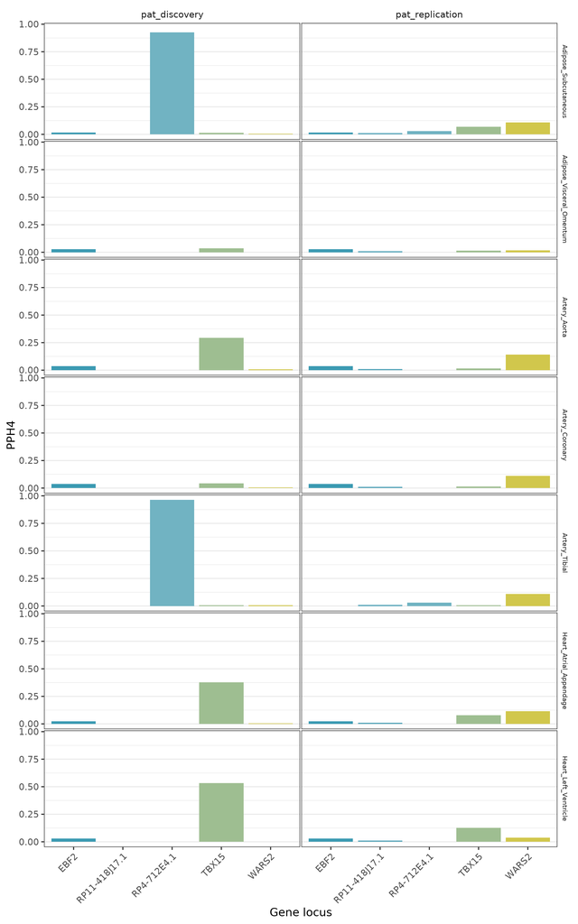

```r
zissou10 <- wes_palette("Zissou1", 10, type = "continuous")

summary_barchart <- results %>%
  ggplot(aes(x = gene_name, y = PP.H4.abf, fill = gene_name)) +
  geom_bar(stat = "identity", show.legend = FALSE) +
  scale_fill_manual(values = zissou10) +
  labs(y = "PPH4", x = "Gene locus") +
  theme(strip.text.y = element_text(size = 8)) +
  facet_grid(rows = vars(eqtl), cols = vars(GWAS_1))

summary_barchart
```

## 4.3 Exploring individual loci

```r
results_dir <- find_coloc_results_paths(directory_to_search = args$coloc_results_dir, pattern_to_search = ".rda")

coloc_files <- results_dir %>%
  dplyr::filter(prior_type == "liberal") %>%  #Filter to match the results we are exploring
  dplyr::inner_join(results,
                    c("gene" = "gene_2",
                      "gwas" = "GWAS_1",
                      "eqtl")) %>%
  dplyr::arrange(eqtl, gwas, gene)
```

### 4.3.1 Sensitivity analysis - significant results

Here we check individual loci showing the Manhattan plots of p values for trait 1 (gwas) and 2 (eQTL), as well as the prior and posterior marginal probability curves. The p values for the SNPs in LD with each other seem to overlap, suggesting that these are real colocalisations. This is further seen in the scatter plots (below) of p values comparing the GWAS results (x axis) and eqtl result (y-axis).

A note regarding alleles: - In the GWAS, Allele 1 is the major allele, Allele 2 is the minor prevalence (GRCh37) allele. - In the GTEx8 eQTLs, Ota eqtl, Ref allele is the allele in the reference genome - this is coloc Al2, and the Alt allele is the effect allele - this is coloc Al1. - So the beta directions should be harmonised between the datasets and not require flipping. This is confirmed in the code below.

For both loci relating to RP4-712E4.1, the sensitivity analysis show that the SNPs for the GWAS (trait 1) and the eQTL (trait 2) do indeed colocalise as the SNPs in reflects the SNPs in LD with the lead SNP.

```r
# Given the eqtl is coding with the ensembl gene id (including suffix number), and I have removed these from the coloc results, I will look up the complete ensembl gene number with suffix from the gtf, using the gene name.
gtf <- rtracklayer::readGFF(args$eqtl_gtf_gencode_26_file) %>%
  as_tibble() %>%
  dplyr::select(gene_id, gene_name) %>%
  dplyr::distinct(gene_name, gene_id)


sig_coloc_files <- coloc_files %>%
  dplyr::filter(PP.H4.abf > 0.75) %>%
  dplyr::left_join(.,
                   gtf,
                   by = "gene_name") # Add in column called gene_id which includes suffix number for ENSG code, to allow easier searching of large eqtl file
```

#### 4.3.1.1 pat_discovery - Adipose_Subcutaneous - RP4-712E4.1

Sensitivity analyses for: pat_discovery - Adipose_Subcutaneous - RP4-712E4.1 - liberal prior

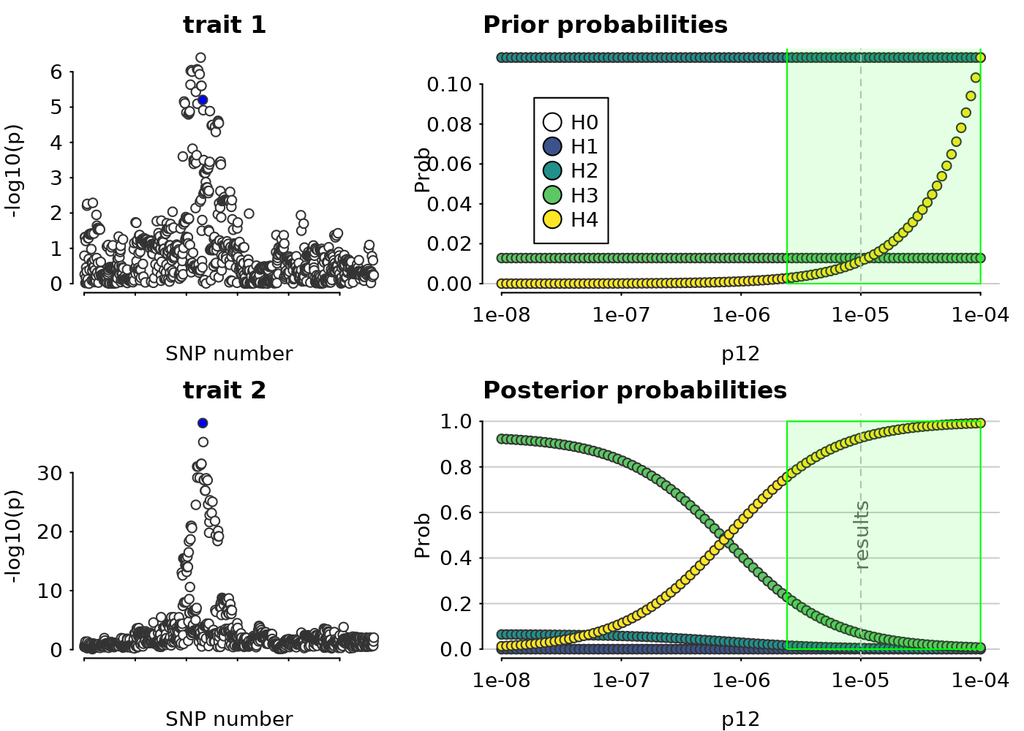

#### 4.3.1.2 pat_discovery - Artery_Tibial - RP4-712E4.1

Sensitivity analyses for: pat_discovery - Artery_Tibial - RP4-712E4.1 - liberal prior

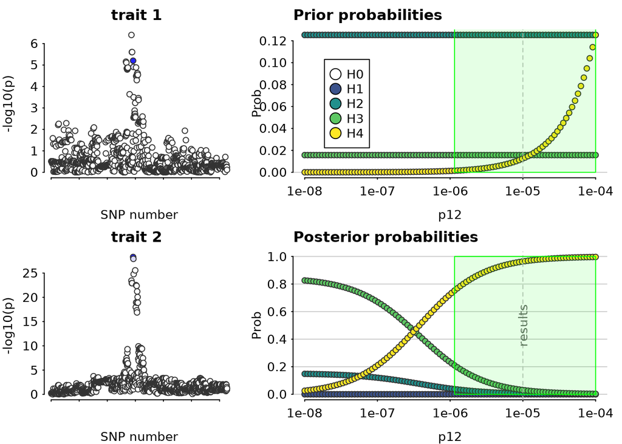

### 4.3.2 p and beta analysis - sig results

```r
# Generate p value and beta comparison plots

coloc_list <- list()

for(i in 1:nrow(sig_coloc_files)){


  gwas_name = sig_coloc_files$gwas[i]
  eqtl_name = sig_coloc_files$eqtl[i]
  gene_name = sig_coloc_files$gene_name[i]
  gene_id_to_search = sig_coloc_files$gene_id[i]
  coloc_locus = str_c(gwas_name, " - ", eqtl_name, " - ", gene_name)

  print(str_c("Locus number is: ", i))
  print(str_c("Locus is: ", coloc_locus))

# Load the original gwas
gwas_path = str_c(args$raw_data_dir, "/", gwas_name, "_tidy_varbeta.txt")
gwas <- fread(gwas_path)

# Load the original eqtl
eqtl_path = str_c(args$raw_data_dir, "/GTEx_Analysis_v8_QTLs-GTEx_Analysis_v8_eQTL_all_associations-", eqtl_name, ".allpairs.txt")
eqtl <- fread(eqtl_path)

print("Filtering eqtl")

eqtl_tidy_gene_filtered <-
  eqtl %>% # Tidy eqtl as per when coloc is run, but without including mafs or varbeta as these are not required.
  dplyr::filter(gene_id == gene_id_to_search) %>%    # Find only the significant genes in the eqtl of interest
  munge_gtex8_eqtl_for_analysis(.)





print("Join eqtl with gwas and check direction")
# Join the gwas and eqtl datasets - this is dorn using the colochelpr function which raises warnings if the datasets are not aligned properly.
locus_gwas_qtl_overlap <- colochelpR::join_coloc_datasets(df1 = gwas,
                                    df2 = eqtl_tidy_gene_filtered,
                                    harmonise = T)

data_to_plot <- locus_gwas_qtl_overlap %>%
  dplyr::select(SNP, gene = gene_name_2, tissue = eqtl_dataset_2,
                Al1_gwas = Al1_1, Al2_gwas = Al2_1, beta_gwas = beta_1, p_gwas = p.value_1,
                Al1_eqtl = Al1_2, Al2_eqtl = Al2_2, beta_eqtl = beta_2, p_eqtl = p.value_2) %>%
  tidyr::separate(col = "SNP", into = c("chr", "pos"), sep = "_", remove = F) %>%
  dplyr::mutate(pos_MB = as.numeric(pos)/1000000,
                log_p_gwas = -log10(p_gwas),
                log_p_eqtl = -log10(p_eqtl))

# Check if Allele 1 and 2 match between datasets, by adding a column which will be TRUE if this is the case
directionality_check <-
  data_to_plot %>%
  dplyr::mutate(matched_effect_and_alt_allele = case_when(Al1_gwas == Al1_eqtl & Al2_gwas == Al2_eqtl ~ TRUE,
                                                          TRUE ~ FALSE),
                swapped_effect_and_alt_allele = case_when(matched_effect_and_alt_allele == FALSE & Al1_gwas == Al2_eqtl & Al2_gwas == Al1_eqtl ~ TRUE,
                                                          TRUE ~ FALSE))



directionality_check %>%
  count(matched_effect_and_alt_allele)

directionality_check %>%
  count(swapped_effect_and_alt_allele)


SNPs_to_exclude <- directionality_check %>%
                             dplyr::filter(matched_effect_and_alt_allele == FALSE, swapped_effect_and_alt_allele== FALSE) %>%
                             .[["SNP"]]

SNPs_to_swap <- directionality_check %>%
                             dplyr::filter(matched_effect_and_alt_allele == FALSE, swapped_effect_and_alt_allele== TRUE) %>%
                             .[["SNP"]]

harmonised_alleles <-
  data_to_plot %>%
  dplyr::filter(!SNP %in% SNPs_to_exclude) %>%
  dplyr::mutate(beta_2 = case_when(SNP %in% SNPs_to_swap ~ (-beta_eqtl),
                                     TRUE ~ beta_eqtl),
                Al1_eqtl = case_when(SNP %in% SNPs_to_swap ~ Al1_gwas,
                                     TRUE ~ Al1_eqtl),
                Al2_eqtl = case_when(SNP %in% SNPs_to_swap ~ Al2_gwas,
                                     TRUE ~ Al2_eqtl))

harmonised_alleles <- harmonised_alleles %>%
   dplyr::mutate(genome_wide_signif = case_when(p_gwas < 1e-5 | p_eqtl < 5e-8 ~ TRUE,
                                               TRUE ~ FALSE))
print("Creating plots")

p_plot <- harmonised_alleles %>%
  ggplot(aes(x = log_p_eqtl, y = log_p_gwas, colour = genome_wide_signif)) +
  geom_point(size = 0.8, alpha = 0.3) +
   scale_colour_manual(values = c("#888888", "#3B9AB2")) +
    geom_hline(yintercept = -log10(5*10^-8), linetype = "dashed") +
  geom_hline(yintercept = -log10(1e-5), linetype = "dashed", colour = "grey50") +
  geom_vline(xintercept = -log10(5*10^-8), linetype = "dashed") +
    ggpubr::stat_cor(method = "spearman", cor.coef.name = "rho", colour = "black", size = 4) +
    labs(x = "-log10(eQTL p-value)",
         y = "-log10(GWAS p-value)",
          colour = "Significant in GWAS or eQTL")


beta_plot <- harmonised_alleles %>%
  ggplot(aes(x = beta_eqtl, y = beta_gwas, colour = genome_wide_signif)) +
  geom_point(alpha = 0.3, size = 0.8) +
    geom_smooth(formula = y ~ x, method = "lm", level = 0.99, colour = "black", size = 0.5, fill = "#4DA2B7") +
      ggpubr::stat_cor(method = "spearman", cor.coef.name = "rho", colour = "black", size = 4) +
    scale_colour_manual(values = c("#888888", "#3B9AB2")) +
    labs(x = "eQTL beta",
         y = "GWAS beta",
          colour = "Significant in GWAS or eQTL")

locus_plot <- (p_plot + beta_plot) +
  plot_layout(guides = "collect") +
  plot_annotation(subtitle = str_c("Coloc results: ", coloc_locus))

print("Saving data")

ggsave(locus_plot,
       file = str_c(args$coloc_figure_path, "/summary_figures/", coloc_locus, ".png"),
       device = "png",
       width = 22, height = 12, units = "cm")

coloc_list[[coloc_locus]] <- list(
    locus_data = harmonised_alleles,
    locus_plot = locus_plot)

print("Locus complete")

}

saveRDS(coloc_list,
        file = str_c(args$coloc_figure_path, "/p_beta_comparisons.Rds"))
```

```r
# Load pre-run coloc summary list
coloc_list <- readRDS(file = str_c(args$coloc_figure_path, "/p_beta_comparisons.Rds"))

locus_plots <- map(coloc_list, ~ .x$locus_plot)
```

### 4.3.3 Explore P and beta values

Exploring p values for individual SNPs contributing to a locus allows confirmation of a true colocalisation - if the SNPs of highest significance for the GWAS are also of significance for the eQTL, it is likely that this is a true signal. In these results, there is a mixture of p values that correlate with each other and those that don’t - a moderately strong signal.  
The beta comparison plots allows exploration re whether the direction of the significant signals align or not, based on the correlation of betas between one trait and another. In this case, both relationships have a positive correlation of betas, suggesting that an increase in gene expression is associated with an increased pericardial volume.

### 4.3.4 p and beta analysis - sig results

#### 4.3.4.1 pat_discovery - Adipose_Subcutaneous - RP4-712E4.1

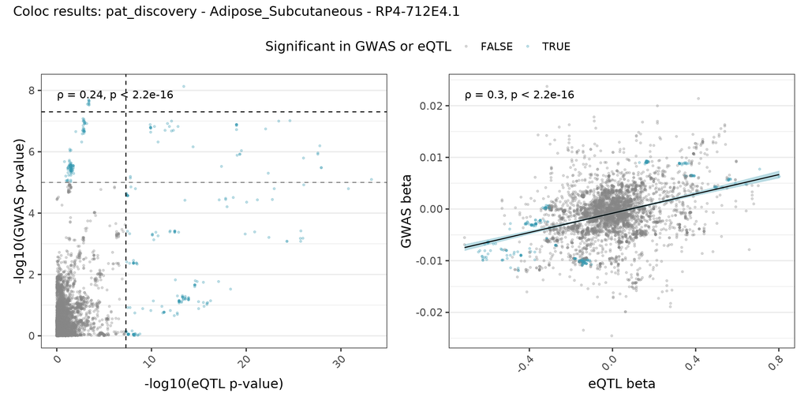

#### 4.3.4.2 pat_discovery - Artery_Tibial - RP4-712E4.1

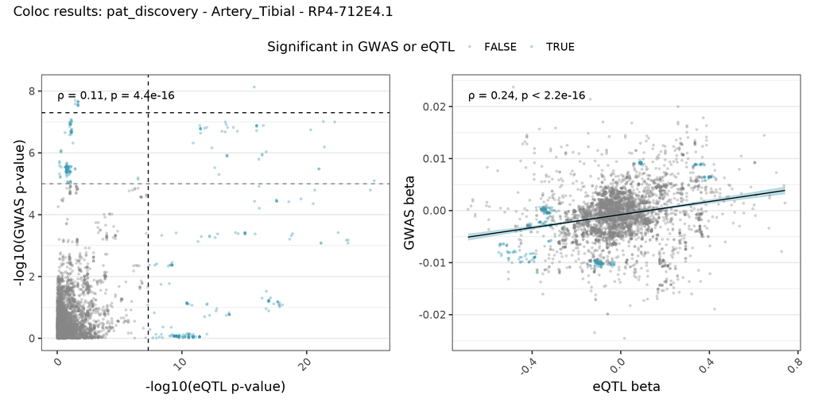